# Graphics activity

Denisse Urenda Castañeda

January 29, 2023

## Problems

### Student activities

The table shows the favorite activities of 200 students. What type of graph would be most appropriate to show the data as parts of a whole?

| Favorite Activity | Percent of Students |
| --- | --- |
| Watching TV | 23% |
| Playing Games | 30% |
| Browsing the Internet | 15% |
| Gardening | 17% |
| Shopping | 15% |

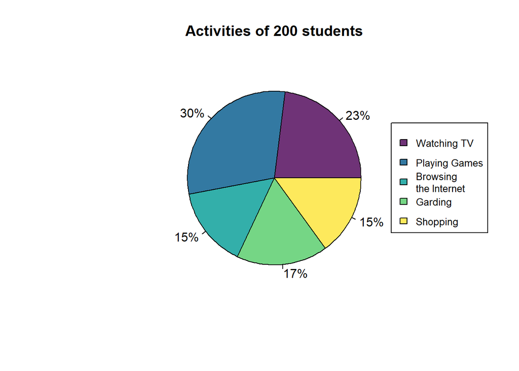

```r
activity = c("Watching TV" = 23, "Playing Games" = 30,
             "Browsing\nthe Internet" = 15, "Garding" = 17,
             "Shopping" = 15)
labels = paste0(activity,"%")
pie(activity, labels, col = hcl.colors(5, alpha = 0.8),
    main = "Activities of 200 students")
legend("right", legend = names(activity), cex = 0.8,
       fill = hcl.colors(5, alpha = 0.8))
```

### Money spent on military

Identify the graph that is most appropriate to represent a data that denotes the amount of money spent on military over a period of time.

A line plot.

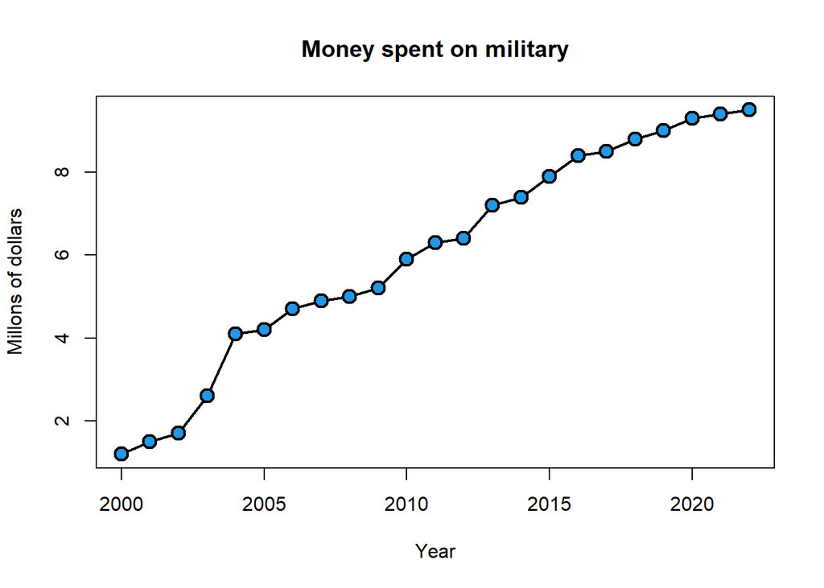

```r
set.seed(2)
money = sort(sample(seq(1,10,0.1),23))
year = 2000:2022
plot(year, money, type = "l", lwd = 2, xlab = "Year",
     ylab = "Millons of dollars",
     main = "Money spent on military")
points(year, money, pch = 21, col = 1, bg = 4, cex = 1.5, lwd = 2)
```

### Time spent to get work

Which graph would be most appropriate to show the time in number of minutes that 25 employees take to travel to the office?

A stem because of the small number of sample.

```r
set.seed(2)
time = round(rnorm(25,25,5))
stem(time, scale = 1)
```

```
##
##   The decimal point is 1 digit(s) to the right of the |
##
##   1 | 3
##   1 | 99
##   2 | 01344
##   2 | 555667799
##   3 | 00334
##   3 | 555
```

### Length of names

A survey was conducted on the length of the names of the students in a class. What type of graph would be most appropriate to show the range of the data?

It depends of the number of students and the range of the data.

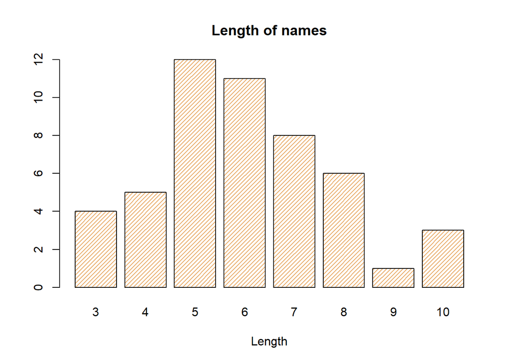

```r
set.seed(47)
lengths = sample(3:15, 50, TRUE, dnorm(3:15, 6, 2))
barplot(table(lengths), density = 25, col = "#E9AE6D",
     xlab = "Length", main = "Length of names")
```

### Most common pets

The table shows the kinds of pets the students have in a class. What type of graph would be most appropriate for the data?

| Pet | Frequency of the Pet |
| --- | --- |
| Birds | 18 |
| Cats | 5 |
| Dogs | 23 |
| Fish | 17 |
| Rabbits | 6 |
| Horse | 4 |

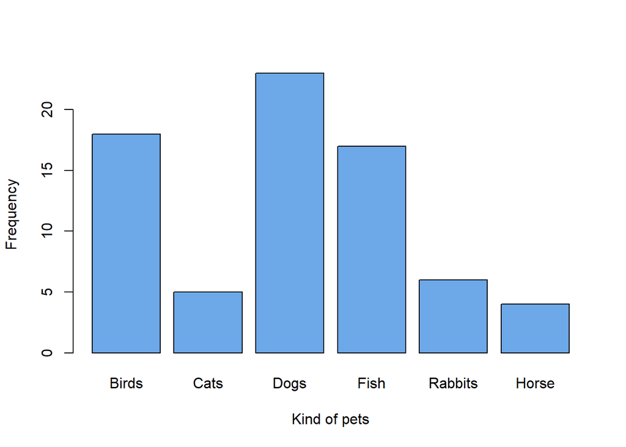

```r
pet = c("Birds","Cats","Dogs","Fish","Rabbits","Horse")
count = c(18,5,23,17,6,4)
barplot(count, names.arg = pet, xlab = "Kind of pets",
        ylab = "Frequency", col = "#6DA8E9")
```

### Yearly average earnings

The table shows the yearly average earnings (in thousands of dollars) for men and women. Which type of graph would be most appropriate for the data?

| Year | 1998 | 1999 | 2000 | 2001 |
| --- | --- | --- | --- | --- |
| Men | 28.9 | 29.3 | 29.6 | 30.2 |
| Women | 19.5 | 20.4 | 22.3 | 22.4 |

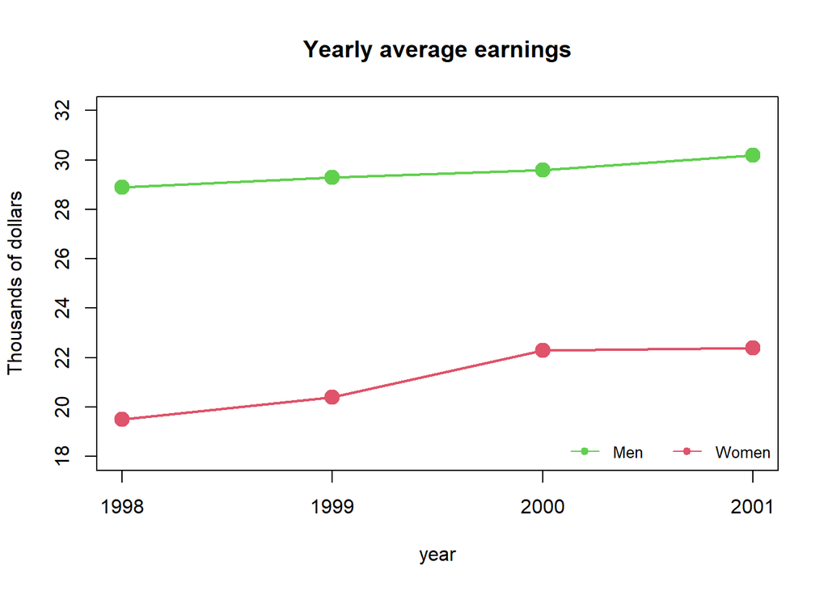

```r
year = 1998:2001
men = c(28.9,29.3,29.6,30.2)
women = c(19.5,20.4,22.3,22.4)
plot(year, men, type = "o", ylim = c(18,32),
     main = "Yearly average earnings", ylab = "Thousands of dollars",
     xaxt = "n", col = 3, pch = 19, cex = 1.5, lwd = 2)
lines(year, women, type = "o", col = 2, pch = 19, cex = 1.5, lwd = 2)
axis(1, year)
legend("bottomright", horiz = T, legend = c("Men","Women"),
       pch = 19, col = 3:2, lty = 1, cex = 0.8, bty = "n")
```

### Weights

The weight of 15 people(in kg) are listed: 34, 49, 23, 54, 35, 64, 40, 53, 52, 76, 48, 21, 47, 34, and 33. Which type of graph is appropriate for the data?

```r
weights = c(34,49,23,54,35,64,40,53,52,76,48,21,47,34,33)
stem(weights, scale = 2)
```

```
##
##   The decimal point is 1 digit(s) to the right of the |
##
##   2 | 13
##   3 | 3445
##   4 | 0789
##   5 | 234
##   6 | 4
##   7 | 6
```

### School enrollment

The table shows the school enrollment between 1992 to 1996. Which type of graph is appropriate for the data?

| Year | Number of students |
| --- | --- |
| 1992 | 65 |
| 1993 | 85 |
| 1994 | 70 |
| 1995 | 70 |
| 1996 | 75 |

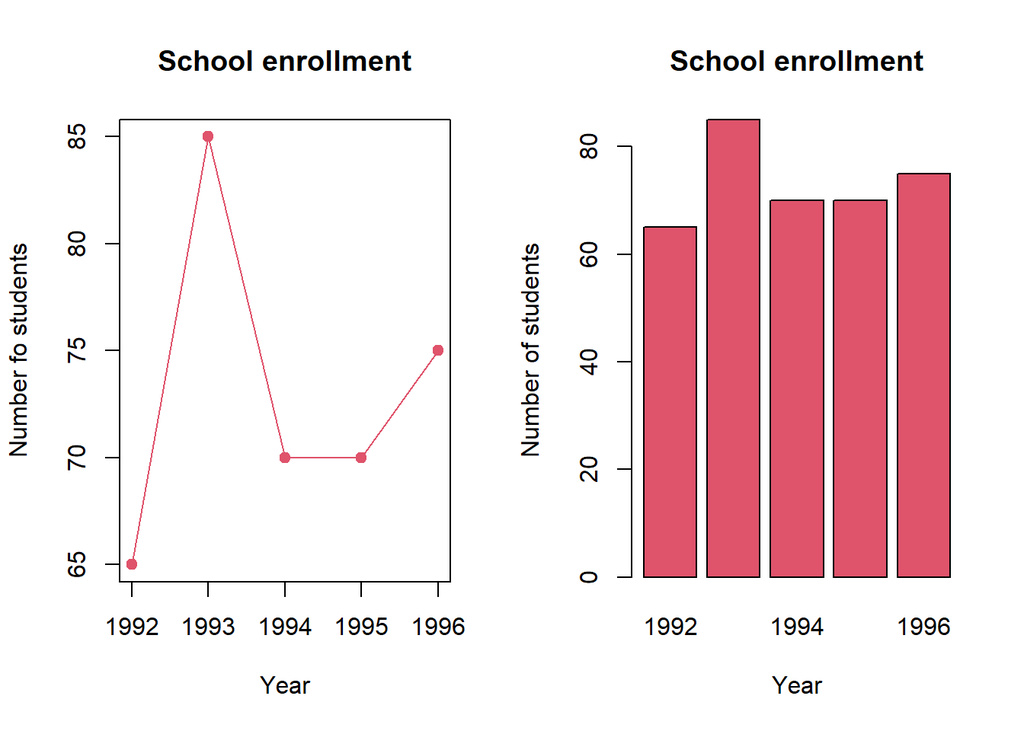

```r
par(mfrow = c(1,2))
year = 1992:1996
students = c(65,85,70,70,75)
plot(year, students, type = "o", ylab = "Number fo students",
     xlab = "Year", main = "School enrollment", pch = 19, col = 2)
barplot(students, names.arg = year, ylab = "Number of students",
        xlab = "Year", main = "School enrollment", col = 2)
```

### Cars sold by color

The table shows the number of cars sold in a week. Which type of graph is appropriate for the data?

| Color of car | Red | White | Orange | Blue |
| --- | --- | --- | --- | --- |
| Number of cars | 15 | 24 | 7 | 11 |

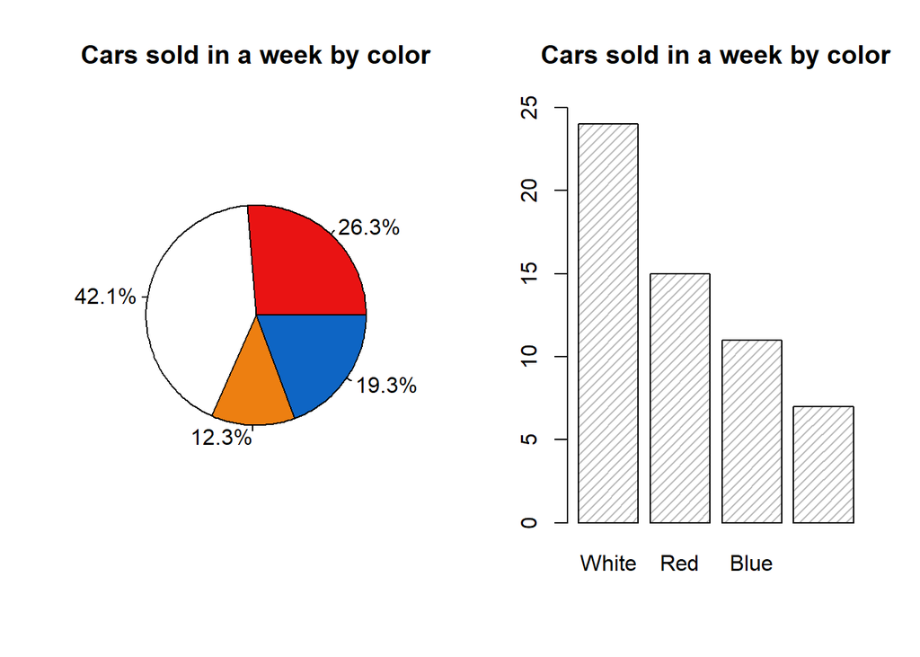

```r
par(mfrow = c(1,2))
cars = c(15,24,7,11)
names(cars) = c("Red","White","Orange","Blue")
colors = c("#E91313","#FFFFFF","#ED7F11","#0E65C4")
pie(cars, labels = paste0(round(cars/sum(cars)*100,1),"%"),
    col = colors, main = "Cars sold in a week by color")
barplot(sort(cars, decreasing = TRUE), density = 20,
        main = "Cars sold in a week by color", ylim = c(0,25))
```

### School days during school year

The table shows the number of school days each month during the last school year.

| Month | Aug | Sep | Oct | Nov | Dec | Jan | Feb | Mar | Apr |
| --- | --- | --- | --- | --- | --- | --- | --- | --- | --- |
| Number of Days | 4 | 18 | 20 | 15 | 12 | 14 | 19 | 14 | 21 |

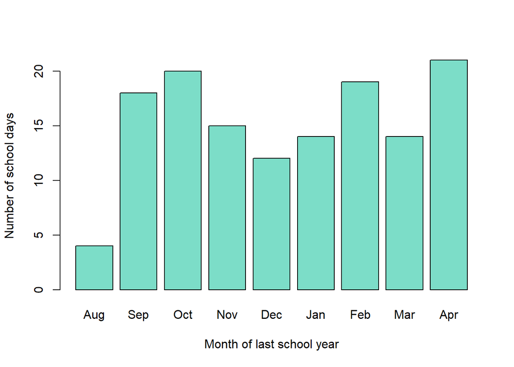

```r
months = month.abb[c(8:12,1:4)]
days = c(4,18,20,15,12,14,19,14,21)
barplot(days, names.arg = months,
        xlab = "Month of last school year",
        ylab = "Number of school days", col = "#7CDDC8")
```

### Which best describe?

Which of the graphs best represents the data?

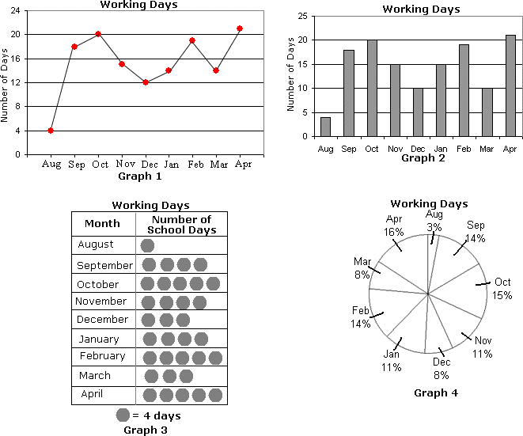

## Source

http://worksheets.tutorvista.com/choosing-the-appropriate-graph-worksheet.html